# Money For Nothing, Clicks for Free (Haha, so funny and it’s also been done before)

Aaron Graybill

10/7/2021

## Introduction

This paper develops and analyzes a model of how artists build and maintain a reputation. This paper pulls from the cultural economics of (Rosen, 1981) and the branding literature (Klein & Leffler, 1981; Shapiro, 1983).

## Model

### Overview

I will now outline a model of how artistic reputation develops over time. To do this, I will first examine the consumer’s problem in which she decides to consume a quantity of different artists’ work taking as given the price and current reputation of the firm. The consumer’s consumption choice will specify a demand function relating quantity consumed to price and current reputation. The artist (firm) takes the demand function and their current reputation as given and sets a price of their work which determines present profit and next period’s reputation. The artist chooses prices in every period that maximize their discounted lifetime profits.

### The Consumer’s Problem

I begin by assuming that there exists a representative consumer who has per-period income $I$. She derives per-period utility according to $U(g,a)$ where $g$ is a numeraire aggregate consumption good, and $a$ is the value of artistic consumption. I assume monotonicity in both goods: $U_g>0$ and $U_a>0$. I further assume that he consumer has decreasing marginal utility from each additional unit of consumption: $U_{gg}<0$ and $U_{aa}<0$. These assumptions are consistent with standard economic assumptions of consumer behavior. Finally, I assume that the consumer’s utility is quasilinear such that $U(g,a)=u(g)+v(a)$. I assume that the consumer is only concerned with consumption in each period and does not consider future utilities.

Now I assume that the value of art, $a$, does not come from a single good but from the portfolio of art that the consumer purchases. In fact, I assume that there exists a continuum of partially substitutable artists indexed by $i\in[0,N]$, where $N$ parametrizes the total number of artists. The consumer derives utility from the amount of art she consumes from each seller, denoted $n(i)$ as well as the reputation of the artist, $r(i)$, that she consumes from. Following (Rosen, 1981), I assume that quantity and reputation are strongly substitutable and can be modeled as a single unit $r(i)n(i)$. This assumption is conducive to the now-canonical monopolistic competition model presented in (Dixit & Stiglitz, 1977). As such I let:
$$v(a)=\left(\int_{0}^N(r_in_i)^\rho di\right)^\frac{1}{\rho}$$

We assume that consumers take the price for a certain artist’s work as given, but that the price level is determined by the reputation of the artist and the number of units that the artist decides to sell. Denote the number of goods sold by the artist $m(i)$ As such, the price is given by $p(r(i),m(i))$. For the consumer’s problem, this is equivalent to $p(i)$.

As such, the consumer’s only choice variables are the number of units to consume from each artist, $n(i)$, and the number of non-art goods she consumes $g$. She chooses this bundle to maximize her utility subject to her budget constraint: $g+\int_0^N n(i)p(i)di\leq I$.

If the consumer commits to spending $E_a$ on artistic goods, then the Marshallian demand for units ofany artist $i$ becomes:
$$n(i)=\left(P\frac{r(i)}{p(r(i))}\right)^\sigma\frac{E_a}{r(i)P}$$

Where the elasticity of substitution is given by $\sigma=\frac{1}{1-\rho}$, and the aggregate reputation-adjusted price level is $P=\left[\int_0^N\left(\frac{p(r(\omega))}{r(\omega)}\right)^{1-\sigma}d\omega\right]^{\frac{1}{1-\sigma}}$. Since there are a continuum of firms, price changes from a finite or countably infinite number of firms has no affect on the aggregate price level, $P$.

Then the consumer chooses how to allocate their income $I$ towards artistic goods $E_a$ and consumption goods $g$. The consumer’s optimal choice of artistic consumption for firm $i$ becomes:
$$n(i)=\left(P\frac{r(i)}{p(r(i))}\right)^\sigma\frac{I-[v']^{-1}\left(\frac{1}{P}\right)}{r(i)P}$$

The expression above gives the Marshallian demand for art from artist $i$ in terms of the price that artist $i$ sets and the reputation they have in the current period. The artist will use this demand function when deciding the optimal price level to set.

### The Artist’s Problem

We model the artist’s problem dynamically. Let the artist have underlying artistic talent $\kappa$ (it can be viewed as a relative of capital). The market is assumed to be monopolistically competitive, so every artist has full control of their price in every period, but price decisions may cause consumers to substitute to other products. The artist takes their current reputation as given. This assumption is used to simplify analysis. Allowing a flexible reputation in the current period obfuscates how reputation evolves by allowing producers to increase there reputation more quickly. As argued above, consumer demand is a function of both price and reputation. However, with the fixed reputation, the artist only has access to a single demand curve in each period. Changes to reputation in future periods shift the artist’s available demand curve. This can be represented graphically in the following way.

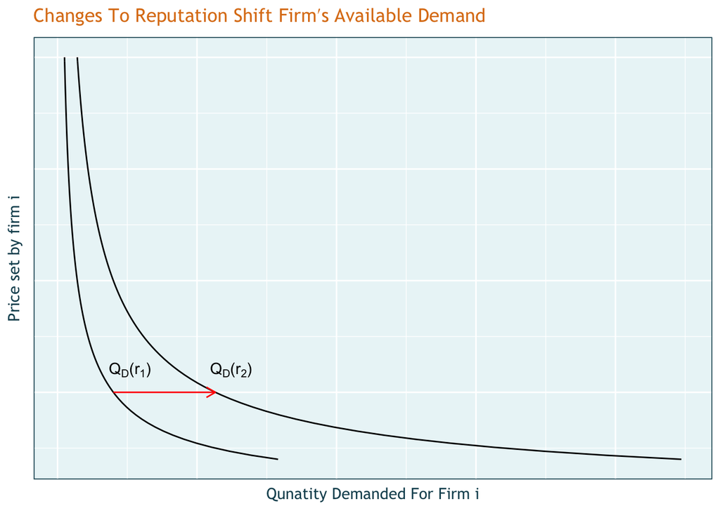

The artist’s problem is not just to maximize current profits, but to maximize the discounted stream of all profits. Unlike traditional growth models, the link tying one period to another is not capital accumulation, but reputation accumulation. I assume that next period’s reputation, $r_{t+1}$, is a function of the current period’s reputation, and the number of units sold. Denote this reputation update function $\mathcal{R}$ such that $r_{t+1}=\mathcal R(n_t,r_t,\kappa)$. The functional form of $\mathcal R$ is integral to this analysis and multiple specifications will be examined and connected to real world scenarios.

We can formulate the artist’s problem two ways. First, I can think of the artist choosing a $p_t$ and $r_{t+1}$ in every period. I can represent this as:
$$\max_{p_t,r_{t+1}}\left\{\sum_{t=0}^\infty\beta^t\left[p_t\cdot n(p_t,r_t)-C(n(p,r_t))-\lambda_t(r_{t+1}-\mathcal R(n(p_t,r_t),r_t,\kappa))\right] \right\}$$

Alternately, I can define the firm’s problem recursively, the agent’s maximal discounted lifetime profit is their profits in this period plus their discounted maximal lifetime from next period onward. The state variable that links one period to the next is their reputation, $r$. As such The Bellman equation is the function $V(r)$ satisfying

$$V(r)=\max_{m}\left\{p(r)m-C(m)+\beta V(r') \ \ s.t. \ \ r'=\mathcal{R}\left(m,r,\kappa\right)\right\}$$

## Exploration of First Order Conditions

I will extensively use the fact that $-\sigma n(\cdot)= p n_p(\cdot)$ (this is a biproduct of CES).

Using the every-period summation model, the first order conditions are that:

$$
$$\begin{align*}
\frac{\partial V}{\partial p}&\colon \beta^t\left[n(\cdot)+p_t n_p(\cdot)-C'(n(\cdot))n_p(\cdot)+\lambda_t \mathcal R_n(n(\cdot),r_t,\kappa)n_p(\cdot)\right]=0\\
\frac{\partial V}{\partial r_{t+1}}&\colon -\beta^t\lambda_t+\beta^{t+1}\left[n_r(\cdot)p_{t+1}-C'(n(\cdot))n_r(\cdot)+\lambda_{t+1}\left(\mathcal R(n(\cdot),r_{t+1}n_r(\cdot)+\mathcal R(n(\cdot,r_{t+1})\right)\right]=0\\
\frac{\partial V}{\partial \lambda_{t}}&\colon \ r_{t+1}=\mathcal R(n(\cdot),r_t)
\end{align*}$$
$$

Before simplifying those expressions, I will briefly interpret them in the context of the traditional theory of the firm by explaining where marginal benefit equals marginal cost. The derivative of lifetime utility with respect to price is akin to the firm’s price setting problem. The artist will continue to raise the price of their work until the marginal benefits of that price increase the marginal cost of that increase in price. The marginal benefit has two channels. First, increases to price have a direct effect on revenue, the $n(\cdot)+p_t n_p(\cdot)$ term in the above first order condition. The overall effect of increasing price on marginal revenue is ambiguous, while the demand and price are non-negative, quantity demanded is decreasing in price, so the sum of the aforementioned terms is ambiguous.

## Bibliography

Dixit, A. K., & Stiglitz, J. E. (1977). Monopolistic Competition and Optimum Product Diversity. *The American Economic Review*, *67*(3), 297–308.

Klein, B., & Leffler, K. (1981). The Role of Market Forces in Assuring Contractual Performance. *The Journal of Political Economy*.

Rosen, S. (1981). The Economics of Superstars. *The American Economic Review*, *71*(5), 845–858.

Shapiro, C. (1983). Premiums for High Quality Products as Returns to Reputations. *The Quarterly Journal of Economics*, *98*(4), 659–679. https://doi.org/10.2307/1881782